# Évaluation n°4 — Suites numériques

# Évaluation n°4

**Classe :** Première - spécialité **Date :** Vendredi 10 Octobre

**Question 1 (2 points).** Soit la suite $(u_n)$ définie pour tout entier naturel $n$ par $u_n=3n^2-2n+1$.

- Calculer les 3 premiers termes de la suite.
- Déterminer l’expression du terme $u_{n-1}$ en fonction de $n$.

**Solution**

- $u_0=3\times 0^2-2 \times 0+1=1$

  $u_1=3\times 1^2-2 \times 1+1=2$

  $u_2=3\times 2^2-2 \times 2 +1=9$
- Soit $n \in \mathbb{N}$,

  $u_{n-1}=3(n-1)^2-2(n-1)+1$

  $u_{n-1}=3n^2-6n+3-2n+2+1$

  $u_{n-1}=3n^2-8n+6$

**Question 2 (2 points).** Soit la suite $(v_n)$ définie par $v_0=1$ et, pour tout entier naturel $n$, $v_{n+1}=0,5v_n+4$. Déterminer les 3 premiers termes de la suite.

**Solution**

$v_0=1$

$v_1=0,5v_0+4=0,5\times 1+4=4,5$

$v_2=0,5v_1+4=0,5 \times 4,5+4=6,25$

**Question 3 (3 points).** Déterminer le sens de variation de la suite définie pour tout entier naturel $n$ par $w_n=n^2-n+2$.

**Solution**

Soit $n \in \mathbb{N}$,

$$\begin{align*}
w_{n+1}-w_n&=(n+1)^2-(n+1)+2-(n^2-n+2)\\
&=n^2+2n+1-n-1+2-n^2+n-2\\
&=2n
\end{align*}$$

Or $2n \geqslant 0$ donc $w_{n+1}\geqslant w_n$

Ainsi, la suite $(w_n)$ est croissante.

**Question 4 (3 points).** On considère la suite $(t_n)$ définie par $t_0=1$ et, pour tout entier naturel $n$, $t_{n+1}=\dfrac{-1}{2}t_n+3$.

- Associer la fonction qui convient et en tracer sa représentation graphique.
- Construire sur ce graphique les quatre premiers termes de la suite.

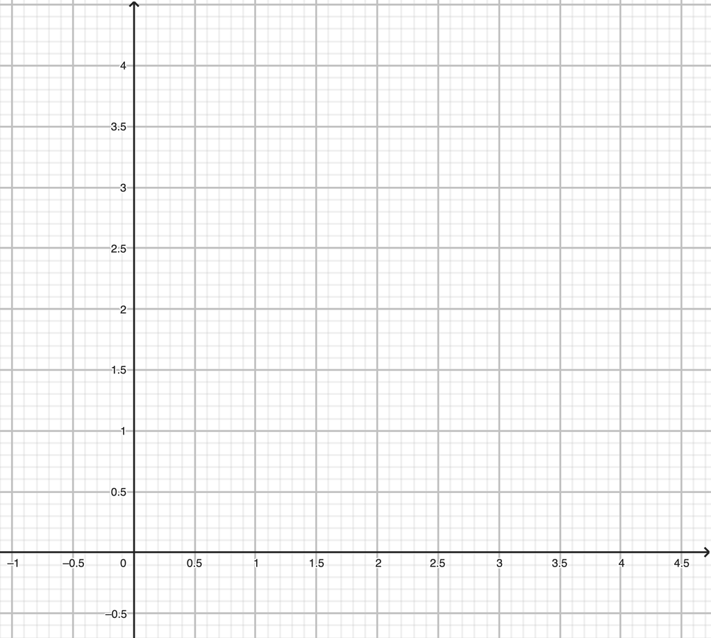

**Solution**

Soit $f$ la fonction définie sur $[0;+\infty[$ par $f(x)=\dfrac{-1}{2}x+3$. On a $f(t_n)=t_{n+1}$.

Soit $C_f$ la courbe représentative de $f$ dans un repère.

Soit $(\Delta)$ la première bissectrice.

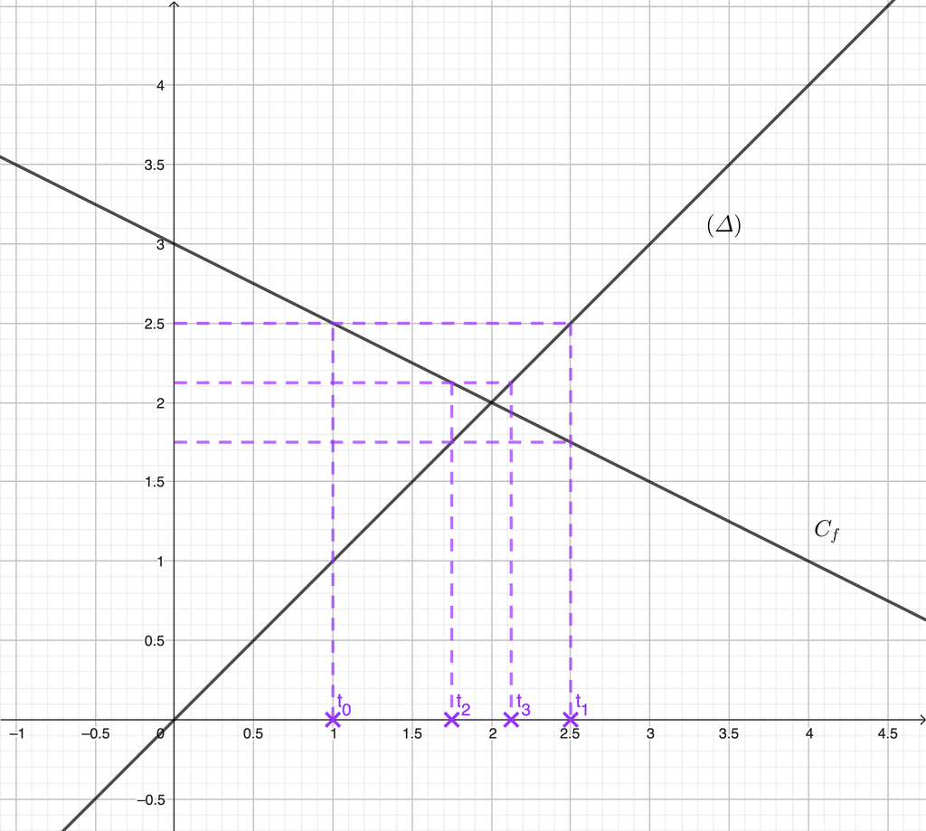